# Exploring 2016 U.S. Primary Election’s Financial Contribution and Expenditure

Nam Truong

November 13, 2015

# 0. Preface:

I choose to do the analize the financial contribution and expenditure for 2016 U.S. Presidential Election data sets provided by [Federal Election Commission](http://fec.gov/) (FEC). Since it’s still very early in the election campaign, the data is rather sparse and is still growing every minute. So, I decided to use the snapshot of the entire dataset instead of just one state. This snapshot was taken at 2:23 pm on Nov 12, 2015.

*Please note that these datasets are a bit special. As transaction records, they only have one numerical variable each: Contribution Amount and Expenditure Amount. As a result, the raw datasets by themselves do not not have a lot to explore. Therefore, much of the analysis is done on the various aggregations of this dataset. Specifically, I will group the transactions by States to get the total contribution per State and compare this aggregated data with each State’s GPD, Population and so on; I will also group the transactions by candidates to measure them against each other on various fronts.*

Along with data from FEC, I also use supplementary datesets to add features, and gain more insights into the primary data.

All datasets in this analysis are included in the **data** folder:

1. CTB.csv: FEC’s Contribution Records
2. EXP.csv: FEC’s Expenditure Records
3. CAN.csv: [FEC’s Candidates Financial Summary](http://www.fec.gov/data/CandidateSummary.do)
4. GDP.csv: [GDP in 2014 (In Million Dollars)](https://www.bea.gov/itable/iTable.cfm?ReqID=70&step=1#reqid=70&step=1&isuri=1)
5. DPI.csv: [Diposable Personal Income in 2014 (In Thousand Dollars)](https://www.bea.gov/itable/iTable.cfm?ReqID=70&step=1#reqid=70&step=1&isuri=1)
6. MED.csv: [Median Household Income in 2014](https://www.census.gov/hhes/www/income/data/statemedian/)
7. POP.csv: [Population in 2014](http://factfinder.census.gov/faces/tableservices/jsf/pages/productview.xhtml)
8. ABR.csv: [State Names and Abbreviations](http://statetable.com/)

# 1. Analysis

## A. Data Summary

```
##      state            name          region       regNo
##  AK     : 1   Alabama   : 1   Midwest  :12   Min.   :1.00
##  AL     : 1   Alaska    : 1   Northeast: 9   1st Qu.:2.00
##  AR     : 1   Arizona   : 1   South    :16   Median :3.00
##  AZ     : 1   Arkansas  : 1   West     :13   Mean   :2.66
##  CA     : 1   California: 1                  3rd Qu.:3.75
##  CO     : 1   Colorado  : 1                  Max.   :4.00
##  (Other):44   (Other)   :44
##    population        contributors      contribution
##  Min.   :  584153   Min.   :  210.0   Min.   :   83628
##  1st Qu.: 1858120   1st Qu.:  738.8   1st Qu.:  553519
##  Median : 4531566   Median : 1728.5   Median : 1406821
##  Mean   : 6363963   Mean   : 3319.4   Mean   : 3248348
##  3rd Qu.: 6982500   3rd Qu.: 3649.0   3rd Qu.: 2903479
##  Max.   :38802500   Max.   :24895.0   Max.   :26913394
##
##   expenditure            GDP                 DPI
##  Min.   :       0   Min.   :2.961e+10   Min.   :2.606e+10
##  1st Qu.:  137642   1st Qu.:8.128e+10   1st Qu.:6.481e+10
##  Median :  863177   Median :2.076e+11   Median :1.624e+11
##  Mean   : 2688699   Mean   :3.440e+11   Mean   :2.573e+11
##  3rd Qu.: 2732310   3rd Qu.:4.454e+11   3rd Qu.:3.289e+11
##  Max.   :26432560   Max.   :2.312e+12   Max.   :1.668e+12
##
##       MHI
##  Min.   :35521
##  1st Qu.:48359
##  Median :54613
##  Mean   :54963
##  3rd Qu.:60653
##  Max.   :76165
##
```

```
##       cand_id       party     candidate          contributors
##  P00003392: 1   REP    :31   Length:60          Min.   :  218
##  P00003962: 1   DEM    :13   Class :character   1st Qu.:  746
##  P00004275: 1   IND    : 6   Mode  :character   Median : 2122
##  P00004861: 1   UNK    : 3                      Mean   : 8155
##  P20000089: 1   NNE    : 2                      3rd Qu.:11450
##  P20002721: 1   OTH    : 2                      Max.   :40027
##  (Other)  :54   (Other): 3                      NA's   :39
##     ind_con            net_con           net_ope_exp
##  Min.   :  365091   Min.   :      204   Min.   :     153
##  1st Qu.: 1013918   1st Qu.:    24688   1st Qu.:   24335
##  Median : 3734242   Median :  1595222   Median :  874693
##  Mean   : 7990391   Mean   : 11586325   Mean   : 5959214
##  3rd Qu.: 9018526   3rd Qu.:  6294434   3rd Qu.: 4750266
##  Max.   :61726374   Max.   :123099212   Max.   :61259426
##  NA's   :39         NA's   :25          NA's   :24
##   full_name             state          region       regNo
##  Length:60          FL     : 7   Midwest  : 8   Min.   :1.000
##  Class :character   TX     : 7   Northeast:11   1st Qu.:2.000
##  Mode  :character   MD     : 4   South    :34   Median :3.000
##                     NY     : 4   West     : 5   Mean   :2.569
##                     VA     : 4   NA's     : 2   3rd Qu.:3.000
##                     OH     : 3                  Max.   :4.000
##                     (Other):31                  NA's   :2
```

## B. Univariate Plots

### Transaction: Contribution Receipt Amount

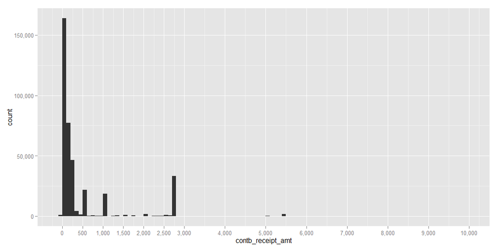

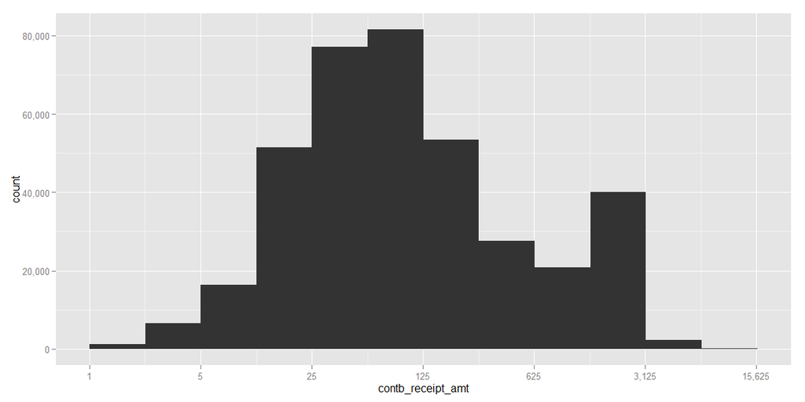

Most contributions fall between $25 and $125. There are also a lot of contributions of $500, $1000 and, oddly, $2700.

### Transactions: Disbursment Amount

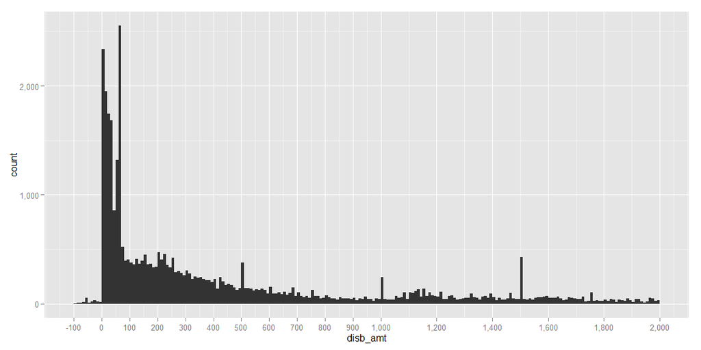

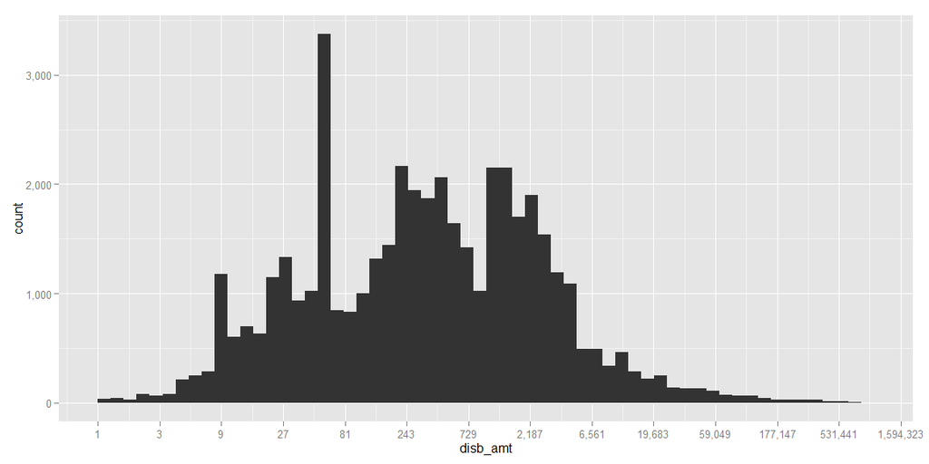

### State: Population

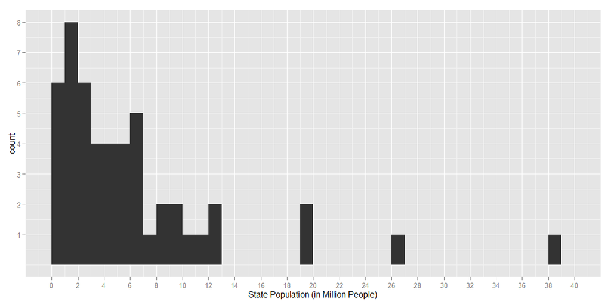

### State: Total Constribution

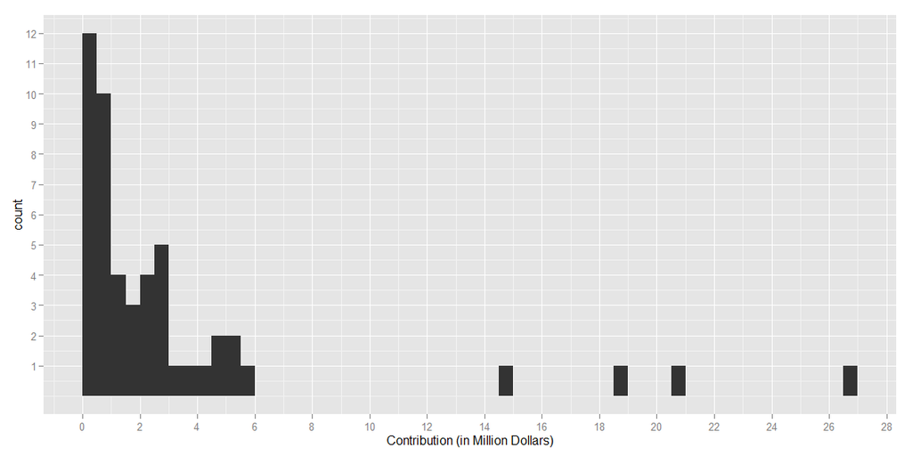

The totals contributions by individuals by most States are less than 2 millions dollars.

### States: Total Expenditure

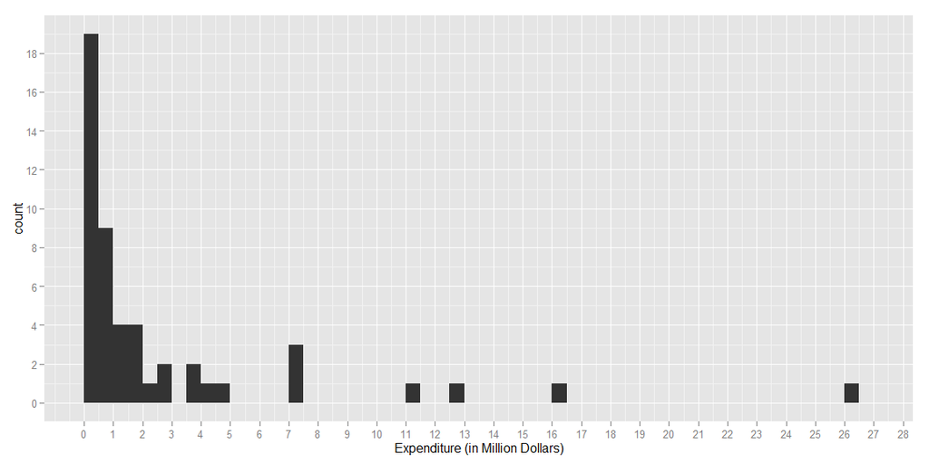

### States: GDP

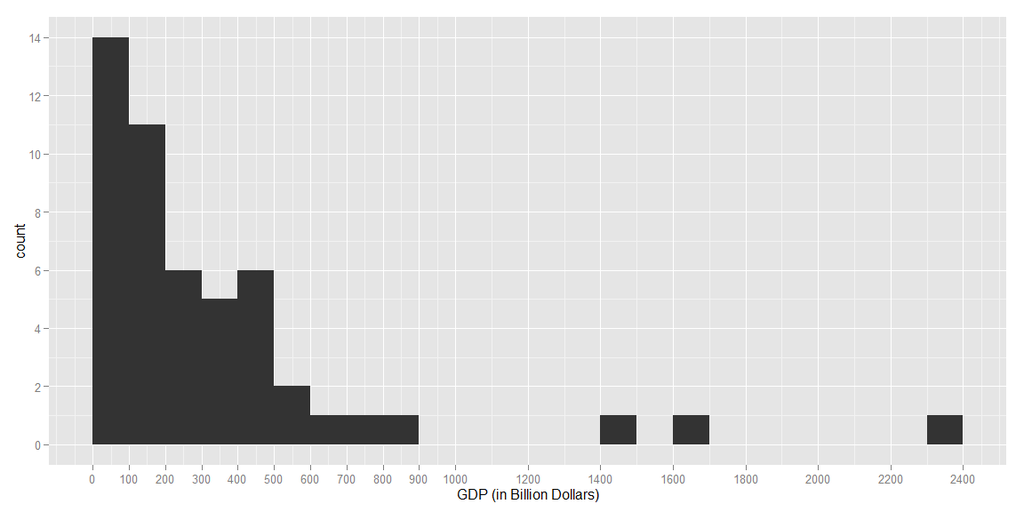

### States: Disposable Personal Income

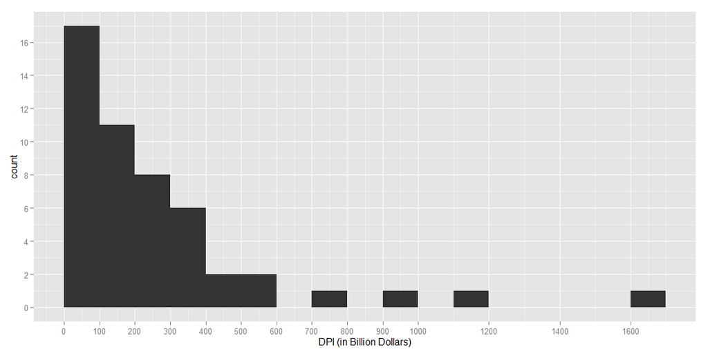

The DPI index is a very similar shape to the GDP index. Most States’ DPI are less than 200 billion dollars.

### States: Median Household Income

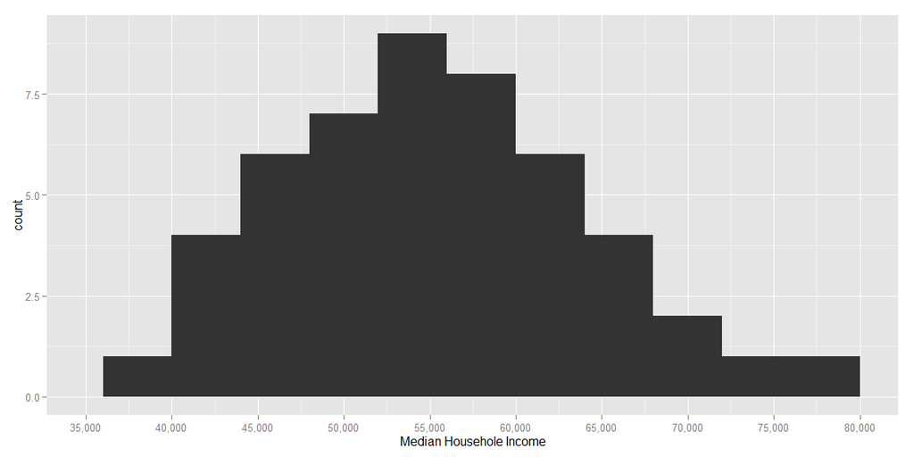

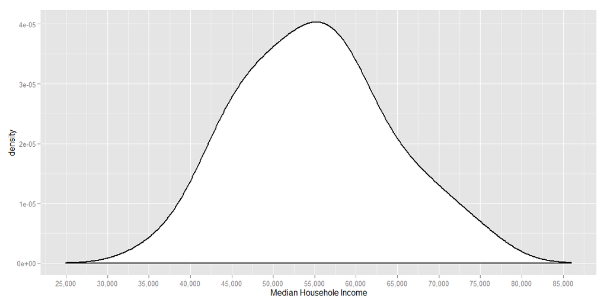

This distribution is almost normal. Most States have Median Household Income between $50,000 and $60,000 with the mode at $55,000.

### Candidates: Number of Individual Contributors

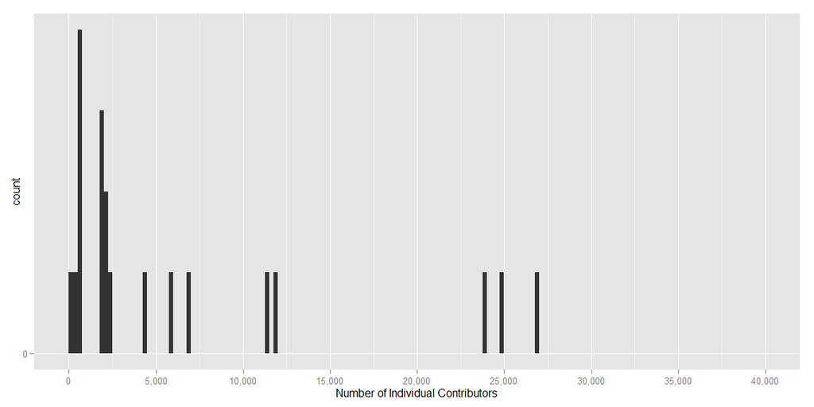

The majority of the listed candidates have almost no contributors

### Candidates: Individual Contribution

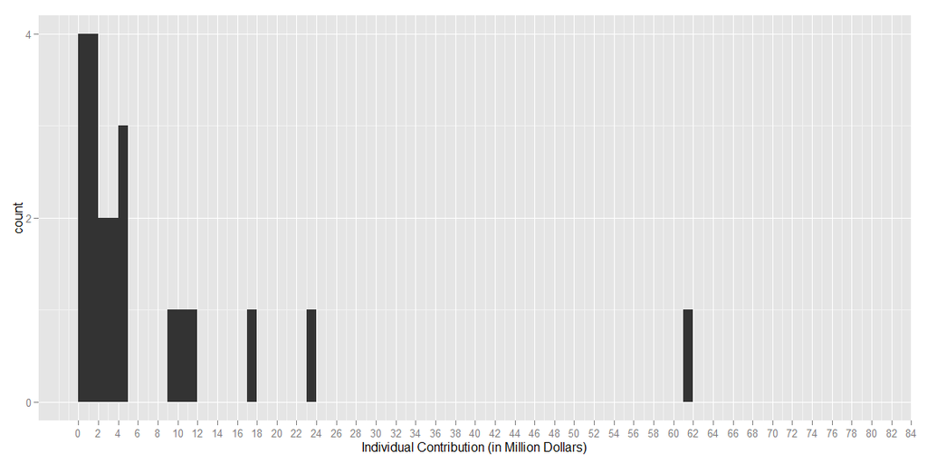

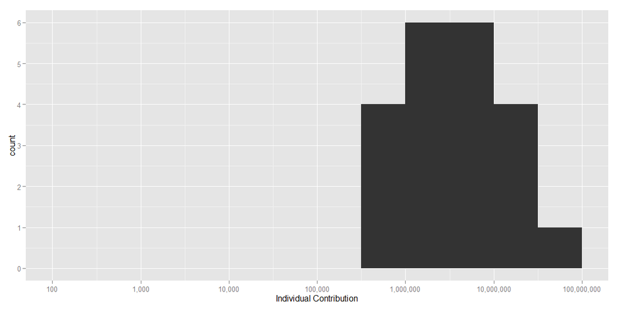

### Candidates: Net Contribution

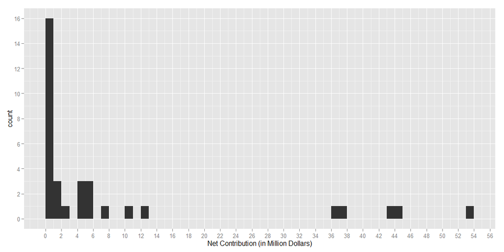

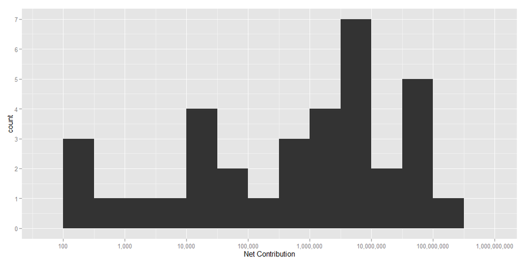

### Candidates: Net Operating Expenditure

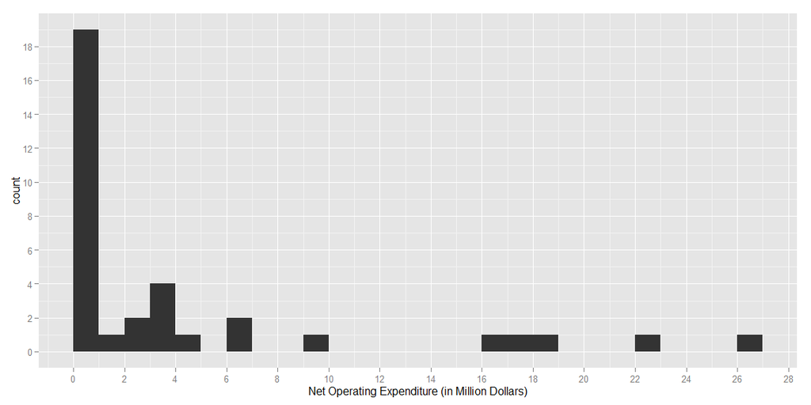

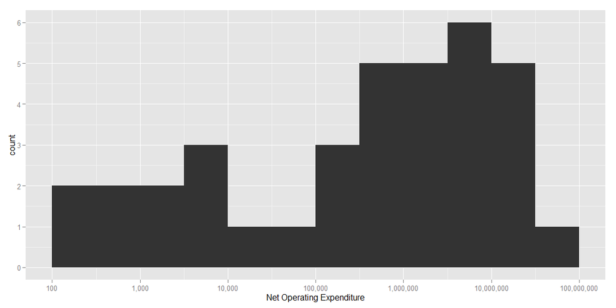

## C. Univariate Analysis

### What is the structure of your dataset?

The main datasets are transaction records of contribution received and spending of 2016 US Presidential Candidates. In the Contribution dataset, each record tell you which candidate the the contribution goes to, the amount of money, and some basic info about the contributor. In the Expenditure dataset, each record tells you which vendor/individual is being paid, the amount spent, the location and so on.

### What is/are the main feature(s) of interest in your dataset?

Since we’re analyzing earning (via donations) and spending of the candidates, the contribution and expenditure features would be the main focus.

### What other features in the dataset do you think will help support your investigation into your feature(s) of interest?

The GDP, MHI, and DPI indices would be great in aiding State Contribution Analysis

### Did you create any new variables from existing variables in the dataset?

I also created Per Capita variables by dividing States variable by the population (e.g. I created GDP_per_capita via dividing GDP by Population)

### Of the features you investigated, were there any unusual distributions? Did you perform any operations on the data to tidy, adjust, or change the form of the data? If so, why did you do this?

The datasets by themselves do not provide us with a grand picture of how this election is going regarding the finance status of each candidate and how much each State is involved. Therefore, I aggregated this data, and combine it with other secondary datasets about US economy to create more interesting data. The results are 3 new datasets as follow:

1. States: This dataset contains the total monetary contribution from each State along with other variables about the State’s economics: Gross Domestic Product (GDP), Median Household Income (MHI), and Disposable Personal Income (DPI)
2. Candidates: This dataset contains the total contribution received, amount of money spent per candidate, and number of contributors per candidate.
3. Cummulations: This dataset contains cummulative contribution, and cummulative expenditure for each candidate over time.

## D. Bivariate Plots

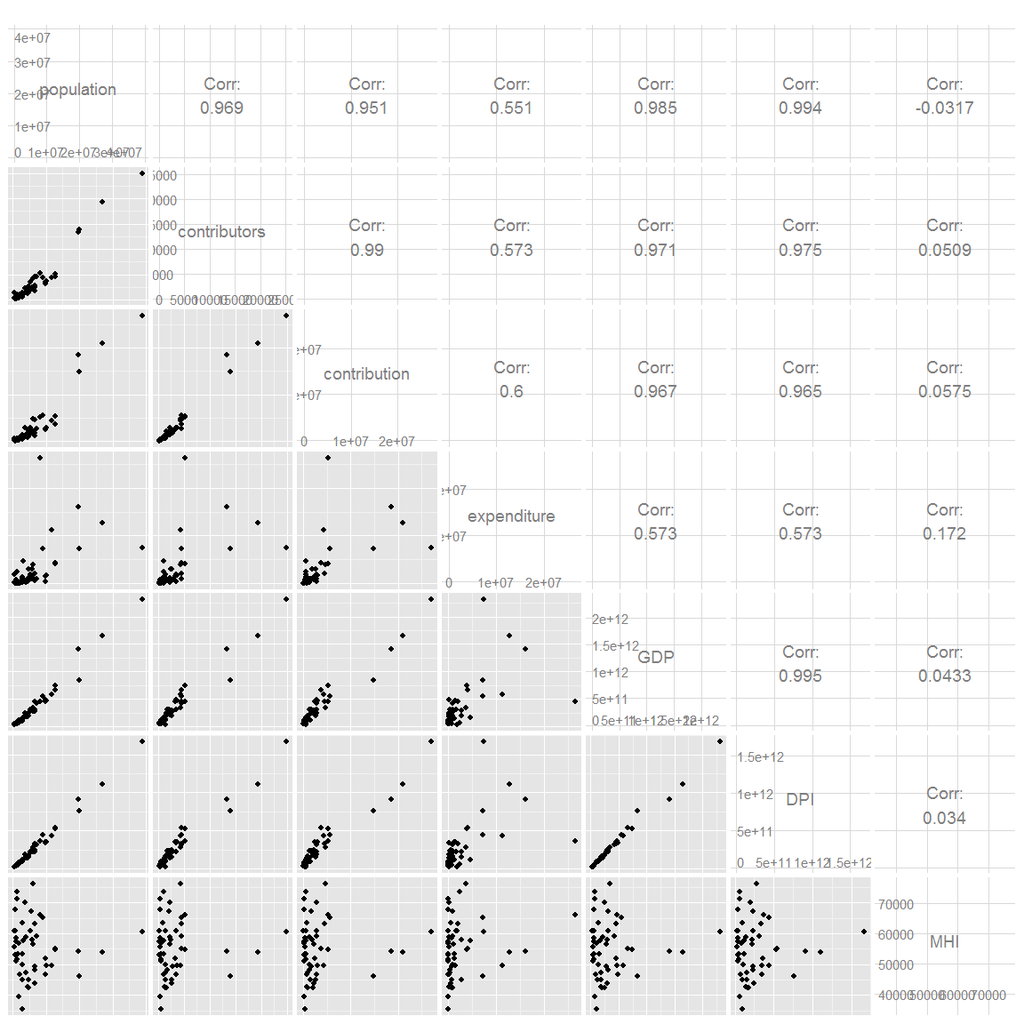

In the States dataset, Contribution is highly correlated with Population, GDP, and DPI. We will look into how other features interact with each other for this dataset.

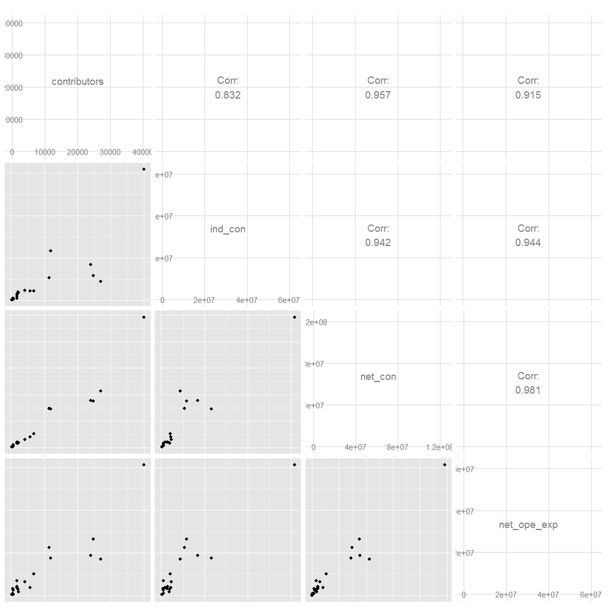

In the Candidates dataset, all numerical value are highly correclted with one another. I will save this dataset for Multivariate section since there’s much to explore for this dataset in this section. Moreover, it’smore fun to break Candidates into parties.

### Individual Contribution Distribution by States

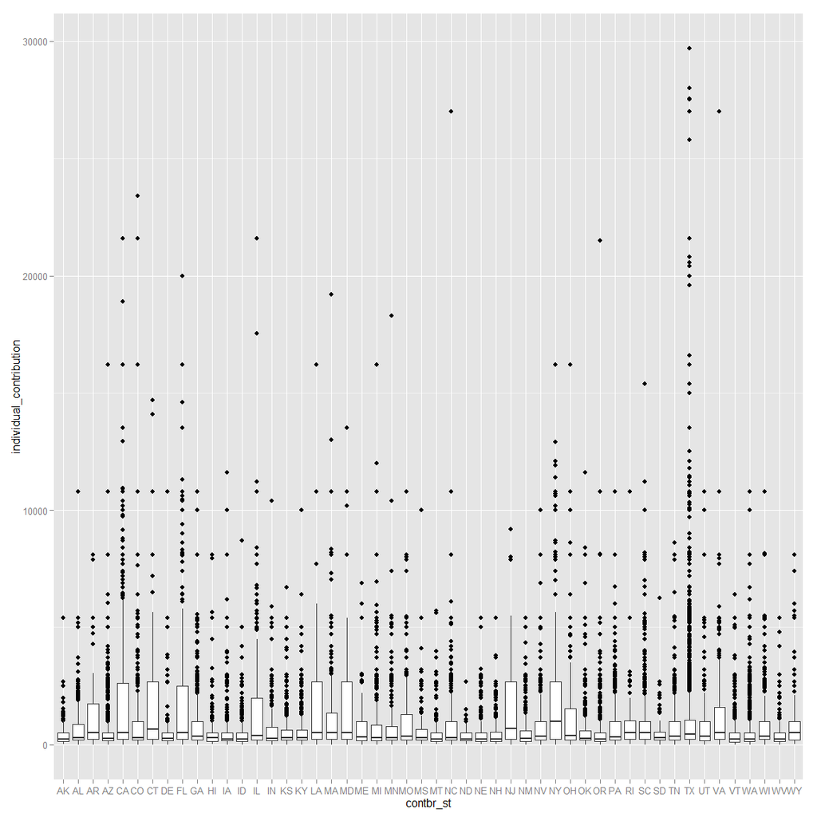

### Comparing States Contribution

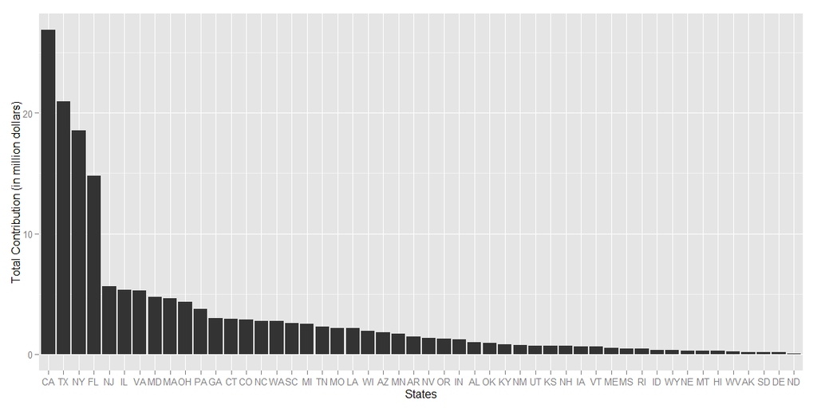

California, Texas, New York, and Florida are way ahead of other states in term of total contribution in this election. However, these are also very populated States. Let’s have a look at how Population and Contribution are related:

### Contribution vs. Population

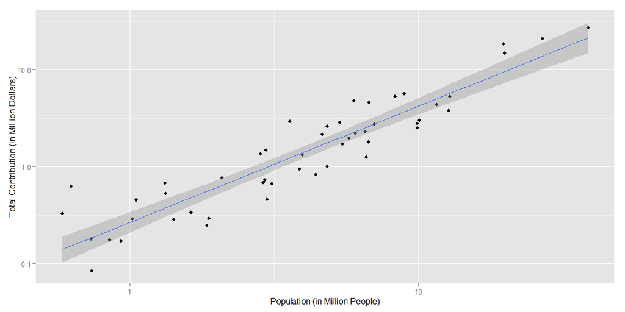

According to this graph, Total Contribution per state is proportional with its population. This could be one of the factors that explains why we have the top contributors the way they are. Would the States’ economy sizes also affect the contribution amount as well?

### Contribution vs. GDP and DPI

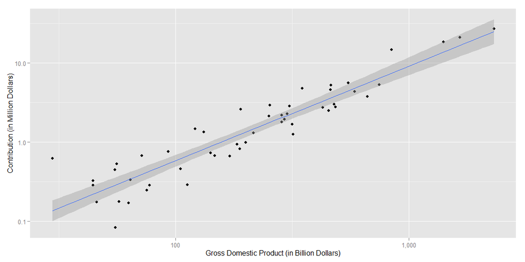

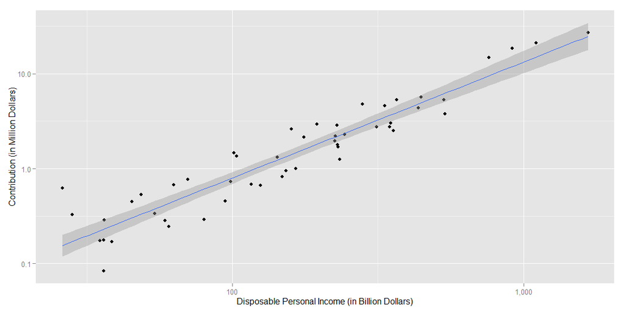

Clearly, a State’s GDP and DPI also explain its citizens’ total contribution to the election. Let’s look at the contribution data at a different angle. How about we compare the number of contributors of each State?

### Comparing States Contributors

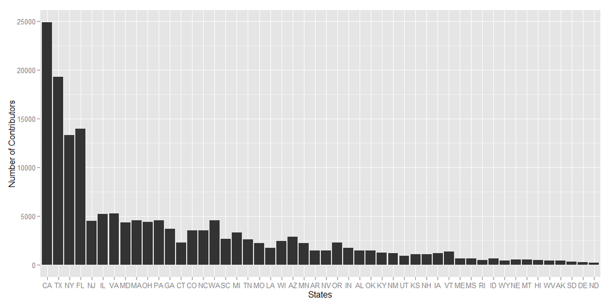

Again, California, Texas, New York, and Florida still dominate the chart and take the lead in number of contributors. I speculate that the number of contributors is highly correlated with the population.

### Comparing States Population and Number of Contributors

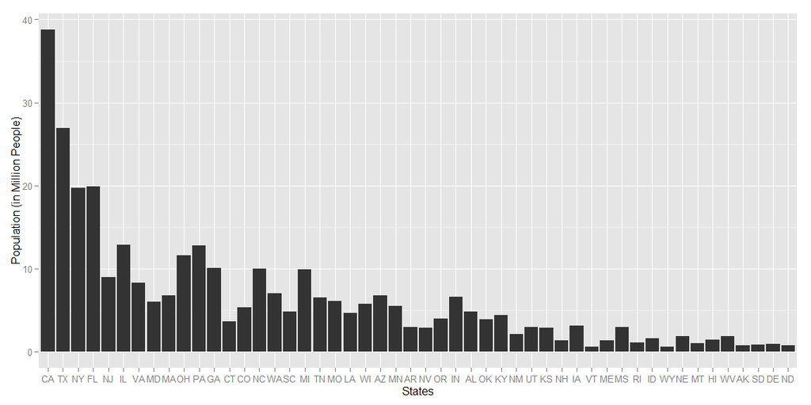

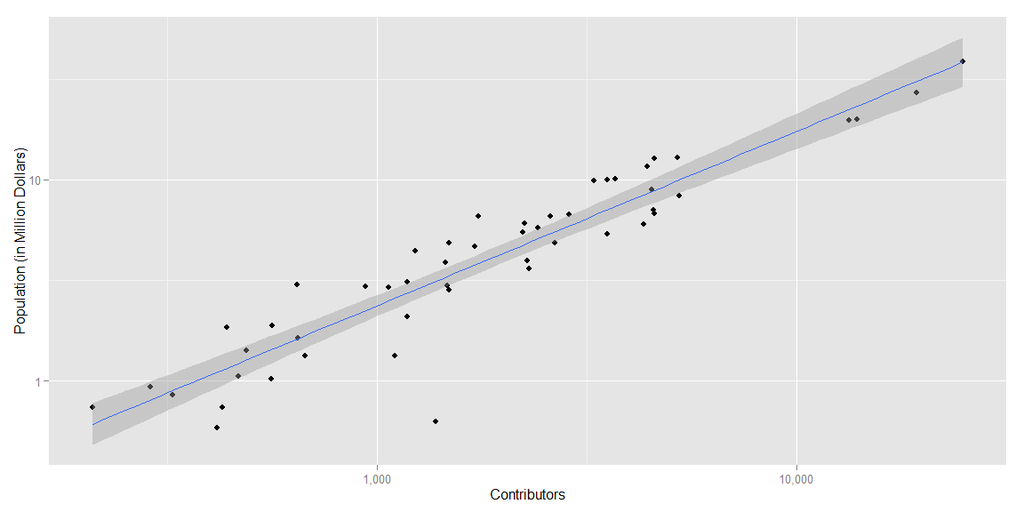

Looks like my spectulation was correct. The number of contributors and population are highly correlated. In this case, population might explain why certain States have more contributors than others.

We need better statistics to compare the States since if we go by number of contributors or total contribution, larger and richer states would “win” easily. Let’s measure the States by two new statistics:

1. Involvement: Number of Contributors : Population ratio
2. Generosity: Average Contribution : GDP per capita ratio

### Comparing States Involvement

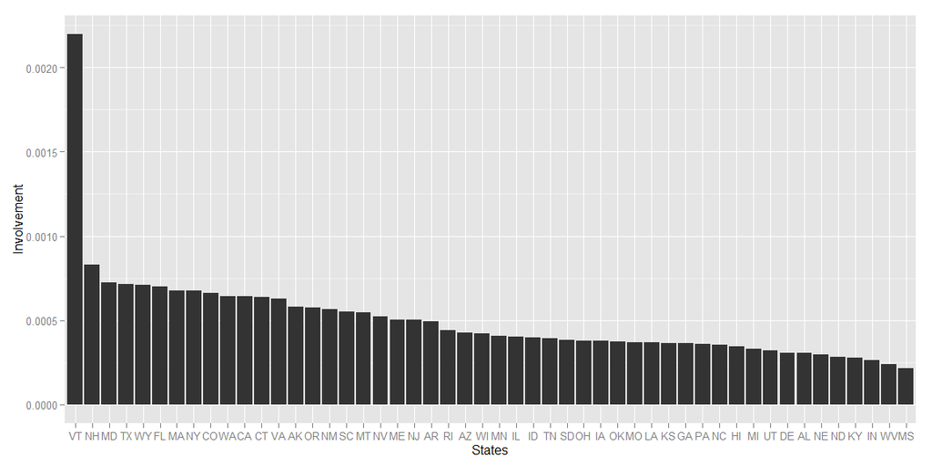

Vermont shoots up to be on top, and beats other States by a very large margin. Its involvement is over 2 times that of the runner up, which is New Hamshire. On the other hand, West Virginia and Mississppi are the least involved States.

I tend to think that people who are better off and have some to spare, are more willing to make donations. Let’s compare Involvement with GDP per capita, DHI per capita, and Median Household Income.

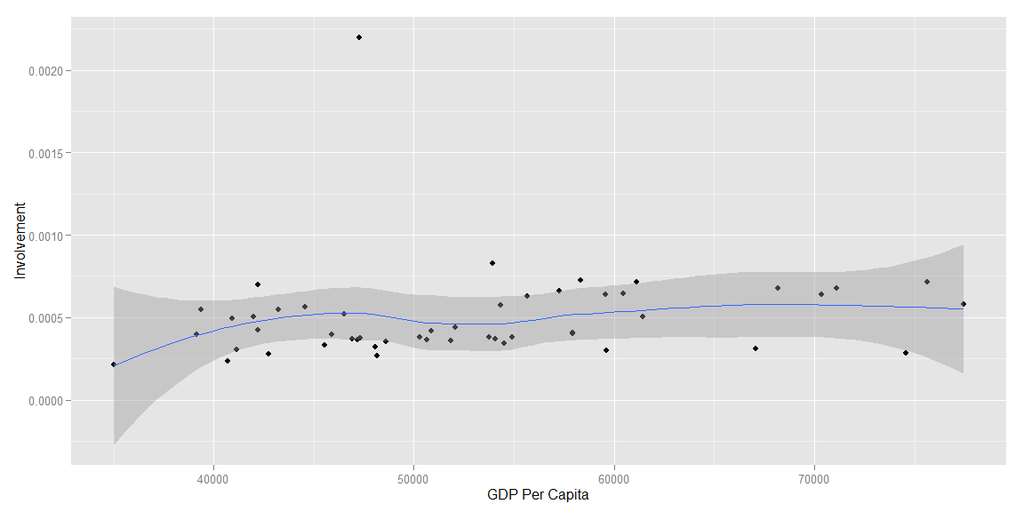

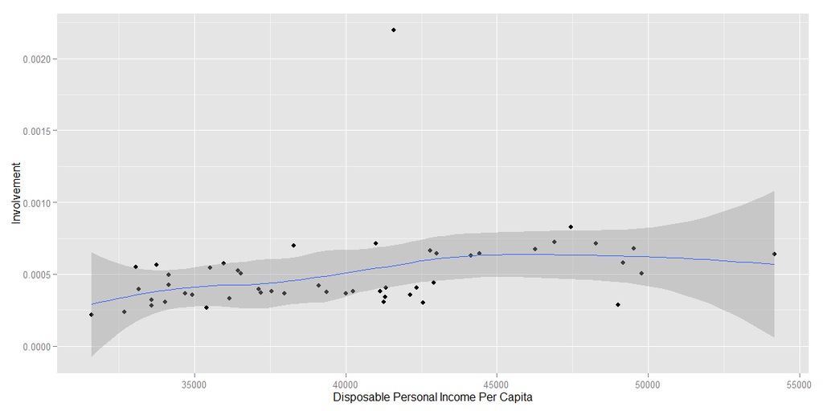

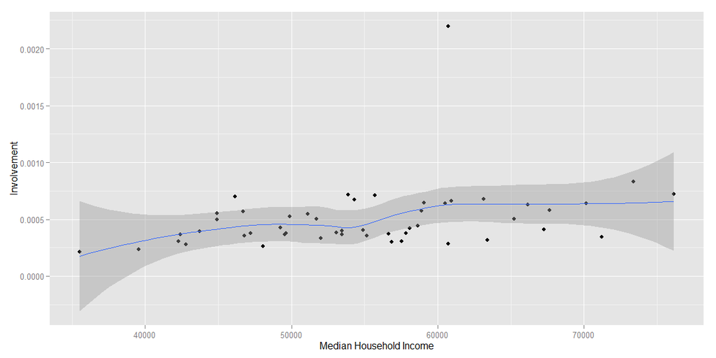

There are no correlations between Involvement and the economics features like I had hoped.